# Отчет по лабораторной работе №4

Базовая настройка HTTP-сервера Apache

Виноградова М.А

Российский университет дружбы народов, Москва, Россия

26 сентября 2026

# Информация

## Докладчик

- Виноградова Мария Андреевна
- студентка НПИбд-02-24
- номер студ. билета 1132240691
- Российский университет дружбы народов
- 1132240691@pfur.ru
- https://github.com/mavinogradova/study_2025-2026_os2

# Цель работы

Приобретение практических навыков по установке и базовому конфигурированию HTTP-сервера Apache.

# Задание

1. Установите необходимые для работы HTTP-сервера пакеты (см. раздел 4.4.1).
2. Запустите HTTP-сервер с базовой конфигурацией и проанализируйте его работу (см. разделы 4.4.2 и 4.4.3).
3. Настройте виртуальный хостинг (см. раздел 4.4.4).
4. Напишите скрипт для Vagrant, фиксирующий действия по установке и настройке HTTP-сервера во внутреннем окружении виртуальной машины server. Соответствующим образом внесите изменения в Vagrantfile (см. раздел 4.4.5).

# Выполнение лабораторной работы

# Установка HTTP-сервера

## Загружаем операционную систему и переходим в рабочий каталог с проектом. Запускаем виртуальную машину server. На виртуальной машине server входим под своим пользователем и открываем терминал. Переходим в режим суперпользователя.

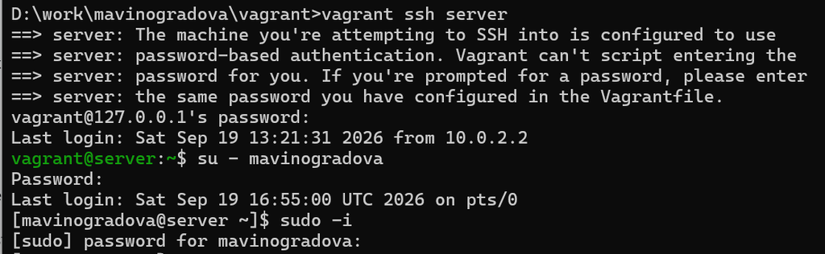

Вход на виртуальную машину server под пользователем mavinogradova и переход в режим суперпользователя

## Просматриваем список доступных групп пакетов с помощью команды `LANG=C yum grouplist`.

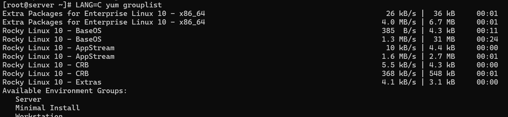

Просмотр доступных групп пакетов командой LANG=C yum grouplist

## В списке доступных групп присутствуют Server, Minimal Install, Workstation. Устанавливаем из репозитория стандартный веб-сервер командой `dnf -y groupinstall "Basic Web Server"`.

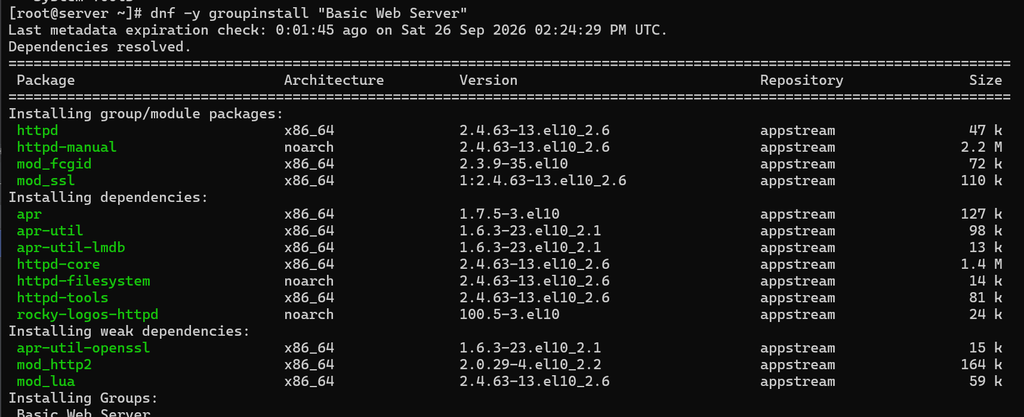

Установка группы пакетов Basic Web Server

# Базовое конфигурирование HTTP-сервера

## Просматриваем и комментируем содержание конфигурационных файлов в каталогах `/etc/httpd/conf` и `/etc/httpd/conf.d`.

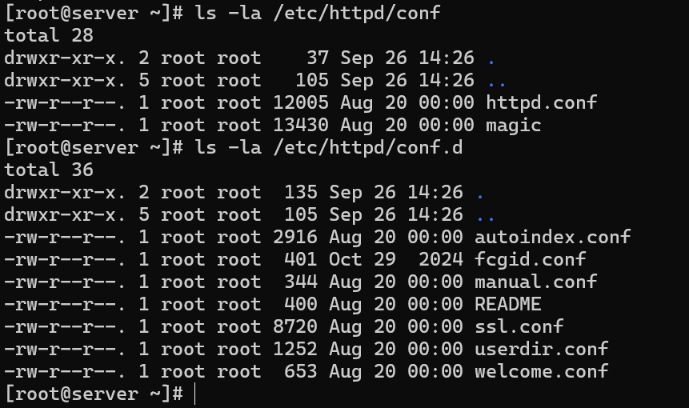

Содержимое каталогов /etc/httpd/conf и /etc/httpd/conf.d

## Вносим изменения в настройки межсетевого экрана узла server, разрешив работу с http.

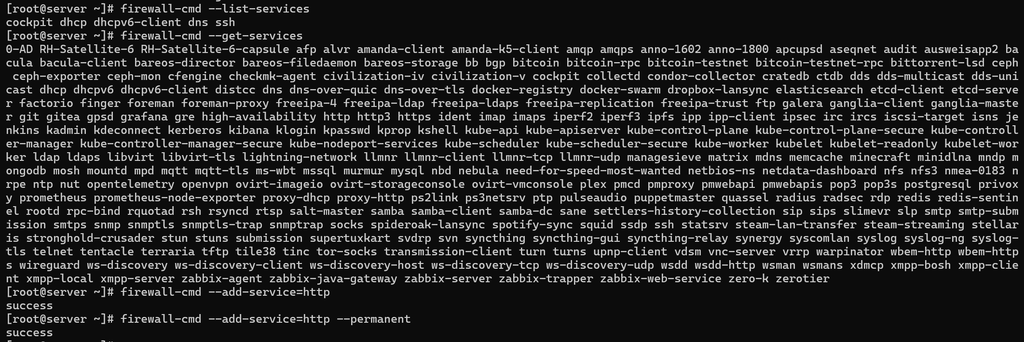

Настройка межсетевого экрана: добавление службы http

## В дополнительном терминале запускаем в режиме реального времени расширенный лог системных сообщений.

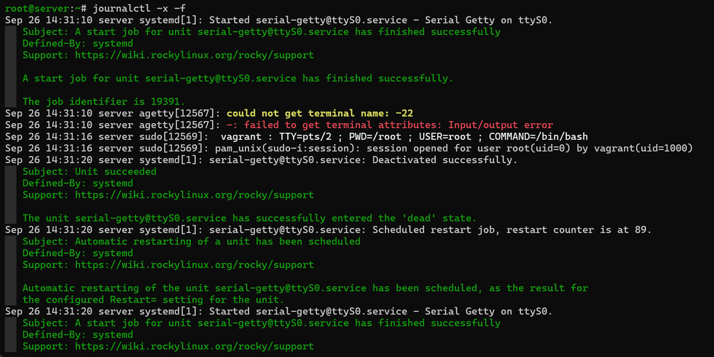

Запуск расширенного лога системных сообщений journalctl -x -f

## В первом терминале активируем и запускаем HTTP-сервер командами `systemctl enable httpd` и `systemctl start httpd`.

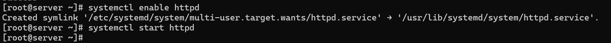

Активация и запуск HTTP-сервера

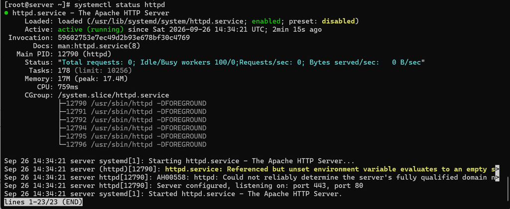

Проверка статуса HTTP-сервера

# Анализ работы HTTP-сервера

## Запускаем виртуальную машину client.

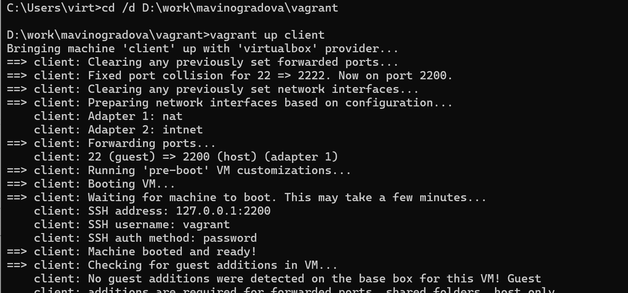

Запуск виртуальной машины client

## На виртуальной машине server просматриваем лог ошибок работы веб-сервера командой `tail -f /var/log/httpd/error_log`.

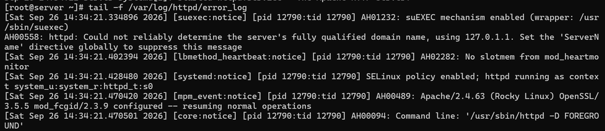

Просмотр лога ошибок работы веб-сервера

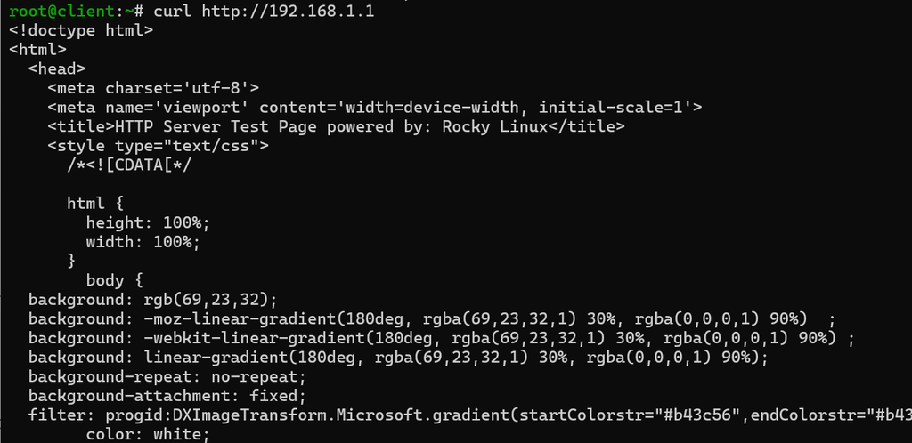

Обращение к веб-серверу с виртуальной машины client

## На виртуальной машине server запускаем мониторинг доступа к веб-серверу командой `tail -f /var/log/httpd/access_log`.

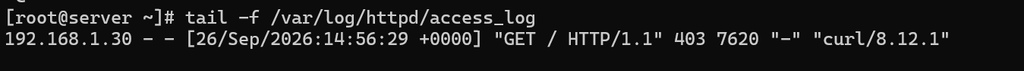

Мониторинг доступа к веб-серверу

# Настройка виртуального хостинга для HTTP-сервера

## Останавливаем работу DNS-сервера для внесения изменений в файлы описания DNS-зон.

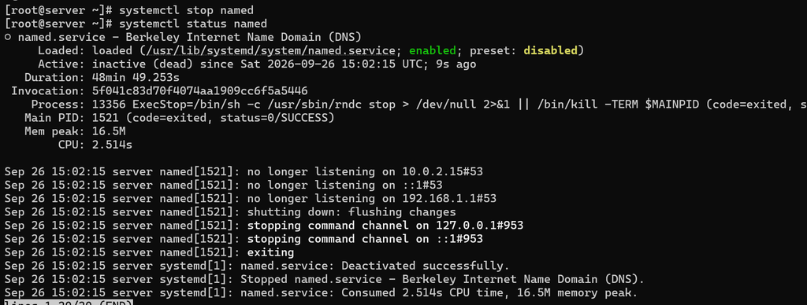

Остановка DNS-сервера

## Добавляем запись для HTTP-сервера в конце файла прямой DNS-зоны `/var/named/master/fz/mavinogradova.net`.

[figure not shown]

Добавление записи www в файл прямой DNS-зоны

## Добавляем запись в конце файла обратной DNS-зоны `/var/named/master/rz/192.168.1`.

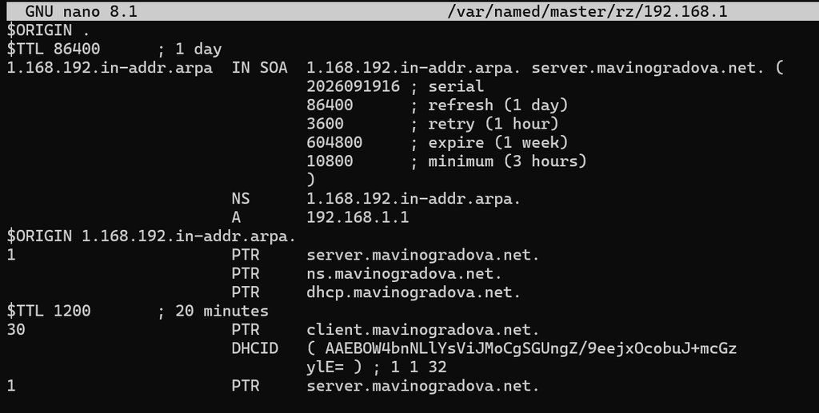

Добавление PTR-записи в файл обратной DNS-зоны

## Перезапускаем DNS-сервер командой `systemctl start named`. В каталоге `/etc/httpd/conf.d` создаём файлы `server.mavinogradova.net.conf` и `www.mavinogradova.net.conf`.

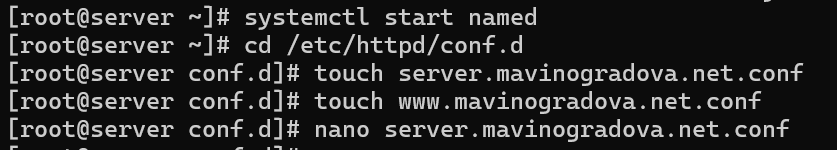

Запуск DNS-сервера и создание конфигурационных файлов виртуальных хостов

## Открываем на редактирование файл `server.mavinogradova.net.conf` и вносим необходимое содержание.

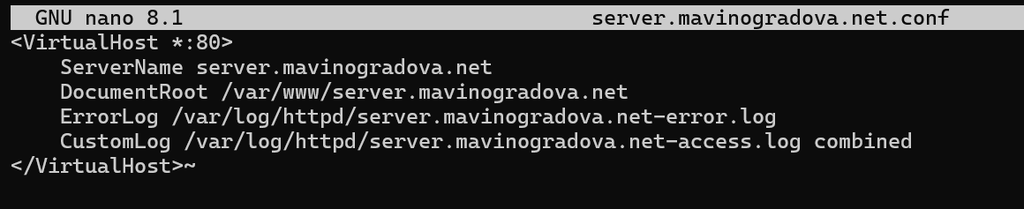

Содержимое файла server.mavinogradova.net.conf

## Открываем на редактирование файл `www.mavinogradova.net.conf` и вносим необходимое содержание.

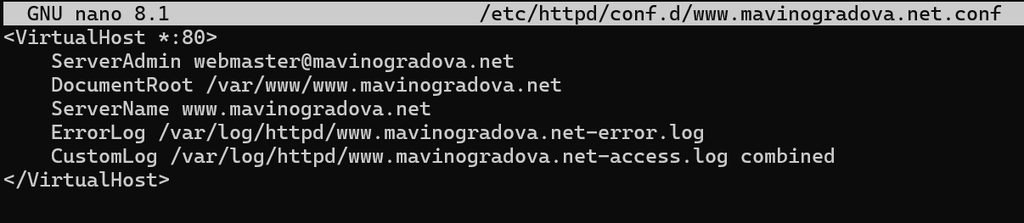

Содержимое файла www.mavinogradova.net.conf

## Переходим в каталог `/var/www/html` и создаём тестовые страницы для виртуальных веб-серверов server.mavinogradova.net и www.mavinogradova.net. Для виртуального веб-сервера server.mavinogradova.net создаём каталог и файл index.html.

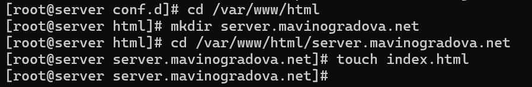

Создание каталога и файла index.html для виртуального веб-сервера server.mavinogradova.net

## Открываем на редактирование файл index.html и вносим содержание для виртуального веб-сервера server.mavinogradova.net.

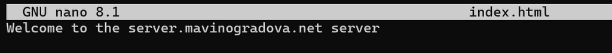

Содержимое index.html виртуального веб-сервера server.mavinogradova.net

## Создаём каталог и файл index.html для виртуального веб-сервера www.mavinogradova.net.

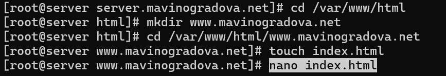

Создание каталога и файла index.html для виртуального веб-сервера www.mavinogradova.net

## Открываем на редактирование файл index.html и вносим содержание для виртуального веб-сервера www.mavinogradova.net.

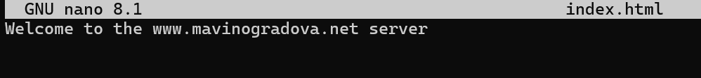

Содержимое index.html виртуального веб-сервера www.mavinogradova.net

## Скорректируем права доступа в каталог с веб-контентом командой `chown -R apache:apache /var/www`.

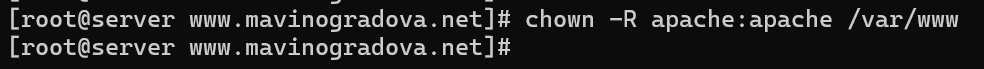

Корректировка прав доступа в каталог с веб-контентом

## Восстанавливаем контекст безопасности в SELinux командами `restorecon -vR /etc`, `restorecon -vR /var/named`, `restorecon -vR /var/www`.

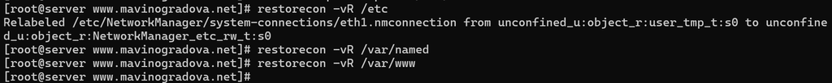

Восстановление контекста безопасности в SELinux

## Перезапускаем HTTP-сервер командой `systemctl restart httpd`.

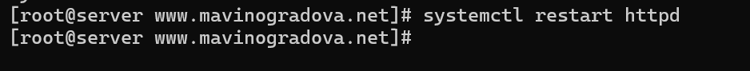

Перезапуск HTTP-сервера

## На виртуальной машине client убеждаемся в корректном доступе к веб-серверу по адресам server.mavinogradova.net и www.mavinogradova.net.

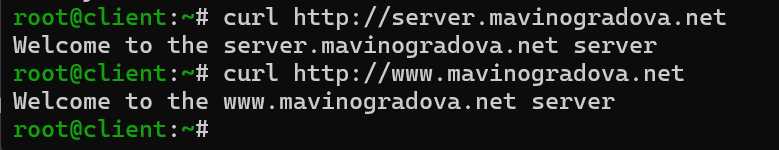

Проверка корректного доступа к виртуальным веб-серверам с машины client

# Внесение изменений в настройки внутреннего окружения виртуальной машины

## Переходим в каталог `/vagrant/provision/server`. Создаём каталоги и копируем конфигурационные файлы и контент.

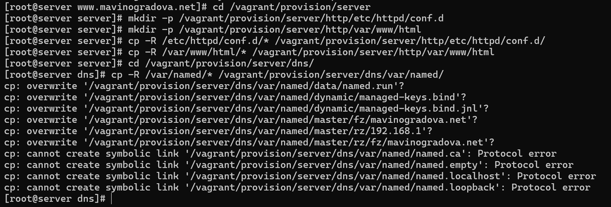

Копирование конфигурационных файлов и зон в каталог provision

## В каталоге `/vagrant/provision/server` создаём исполняемый файл `http.sh` командами `touch http.sh` и `chmod +x http.sh`.

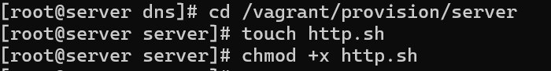

Создание исполняемого файла http.sh

## Открыв файл http.sh на редактирование, прописываем в нём скрипт провижининга.

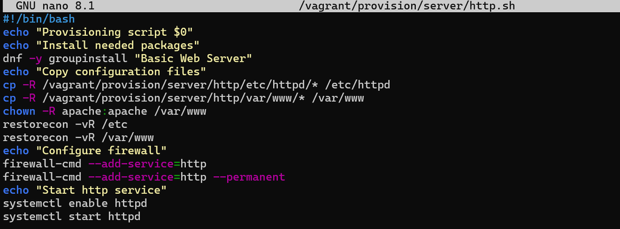

Содержимое скрипта провижининга http.sh

## Для отработки созданного скрипта во время загрузки виртуальных машин в конфигурационном файле Vagrantfile добавляем запись.

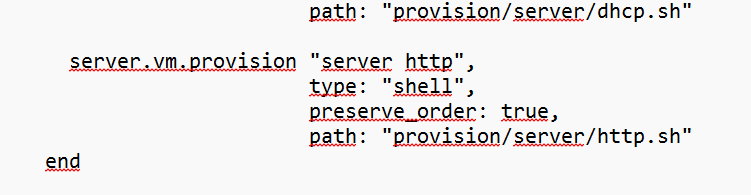

Добавление записи о провижининге в Vagrantfile

# Выводы

В ходе лабораторной работы были приобретены практические навыки по установке и базовому конфигурированию HTTP-сервера Apache. Были установлены необходимые для работы HTTP-сервера пакеты (группа «Basic Web Server»), включающие httpd, httpd-manual, mod_fcgid, mod_ssl и зависимости. HTTP-сервер запущен с базовой конфигурацией, проанализирована его работа с помощью логов `/var/log/httpd/error_log` и `/var/log/httpd/access_log`. Настроен виртуальный хостинг по двум DNS-адресам — server.mavinogradova.net и www.mavinogradova.net. Написан скрипт для Vagrant `http.sh`, фиксирующий действия по установке и настройке HTTP-сервера во внутреннем окружении виртуальной машины server, и внесены соответствующие изменения в Vagrantfile.